# Project Python Foundations: FoodHub Data Analysis

Catplot

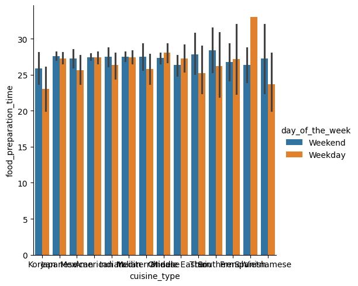

```python
sns.catplot(data=df, x='cuisine_type', y='food_preparation_time', hue='day_of_the_week', kind='bar')
plt.show()
```

*Weekday vs. Weekend Differences: Some cuisines show notable shifts in prep time depending on the day. For instance:*

*Cuisine-Specific Trends:*

Let`s check how long it takes to prepare different cuisines on weekdays versus weekends

```python
df.groupby(['cuisine_type', 'day_of_the_week'])['food_preparation_time'].mean()
```

| cuisine_type | day_of_the_week | food_preparation_time |
| --- | --- | --- |
| American | Weekday | 27.408284 |
|  | Weekend | 27.453012 |
| Chinese | Weekday | 28.076923 |
|  | Weekend | 27.331288 |
| French | Weekday | 27.200000 |
|  | Weekend | 26.769231 |
| Indian | Weekday | 26.333333 |
|  | Weekend | 27.489796 |
| Italian | Weekday | 27.417582 |
|  | Weekend | 27.512077 |
| Japanese | Weekday | 27.281481 |
|  | Weekend | 27.602985 |
| Korean | Weekday | 23.000000 |
|  | Weekend | 25.909091 |
| Mediterranean | Weekday | 25.785714 |
|  | Weekend | 27.531250 |
| Mexican | Weekday | 25.625000 |
|  | Weekend | 27.226415 |
| Middle Eastern | Weekday | 27.235294 |
|  | Weekend | 26.375000 |
| Southern | Weekday | 26.166667 |
|  | Weekend | 28.363636 |
| Spanish | Weekday | 33.000000 |
|  | Weekend | 26.363636 |
| Thai | Weekday | 25.250000 |
|  | Weekend | 27.866667 |
| Vietnamese | Weekday | 23.666667 |
|  | Weekend | 27.250000 |

**dtype:** float64

*Spanish cuisine drops dramatically from 33.0 to 26.36 minutes. That’s a 6.64-minute decrease—possibly due to streamlined menus or weekend staffing differences.*

*Vietnamese and Thai dishes also show notable increases in prep time, suggesting more elaborate weekend orders or slower workflows.*

*Southern cuisine goes from 26.17 to 28.36 minutes—a 2.2-minute spike.*

*Indian and Mediterranean also take longer to prepare over weekends—perhaps reflecting increased complexity or demand.*

let`s check how food preparation time varies with delivery time

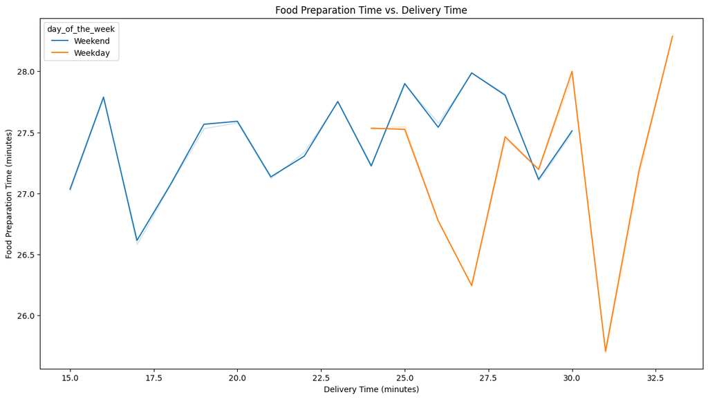

```python
plt.figure(figsize=(15, 8))
sns.lineplot(data=df, x='delivery_time', y='food_preparation_time', hue='day_of_the_week', errorbar=('ci', False))
plt.ylabel('Food Preparation Time (minutes)')
plt.xlabel('Delivery Time (minutes)')
plt.title('Food Preparation Time vs. Delivery Time')
plt.show()
```

*X-Axis (Delivery Time): Ranges from 15 to 32.5 minutes—this is how long it takes to deliver meals.*

*Y-Axis (Prep Time): Varies from 26 to 28 minutes—not a huge spread, but meaningful.*

Let`s visualise all the outliers present in data together

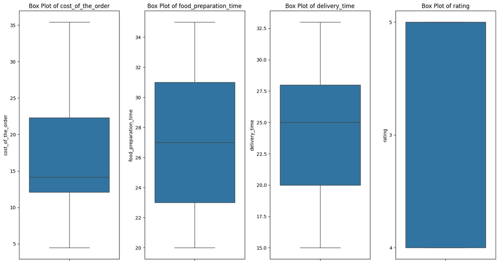

```python
numeric_columns = ['cost_of_the_order', 'food_preparation_time', 'delivery_time', 'rating']
plt.figure(figsize=(15, 8))

for i, variable in enumerate(numeric_columns):
    plt.subplot(1, 4, i + 1)
    sns.boxplot(data=df, y=variable, whis=1.5)
    plt.title(f'Box Plot of {variable}')

plt.tight_layout()
plt.show()
```

### **Question 13:** The company wants to provide a promotional offer in the advertisement of the restaurants. The condition to get the offer is that the restaurants must have a rating count of more than 50 and the average rating should be greater than 4. Find the restaurants fulfilling the criteria to get the promotional offer. [3 marks]

```python
# Write the code here
df['rating'] = pd.to_numeric(df['rating'], errors='coerce')
grouped = df.groupby('restaurant_name')
rating_stats = grouped['rating'].agg(['count', 'mean']).reset_index()

# Filter for restaurants with rating count > 50 and average rating > 4
promotional_restaurants = rating_stats[(rating_stats['count'] > 50) & (rating_stats['mean'] > 4)]

print("Restaurants fulfilling the criteria for the promotional offer:")
print(promotional_restaurants)
```

```
Restaurants fulfilling the criteria for the promotional offer:
               restaurant_name  count      mean
20   Blue Ribbon Fried Chicken     64  4.328125
21           Blue Ribbon Sushi     73  4.219178
136                Shake Shack    133  4.278195
153          The Meatball Shop     84  4.511905
```

#### Observations:

*Each of these restaurants: Has more than 50 ratings, Maintains an average rating above 4.0.*

### **Question 14:** The company charges the restaurant 25% on the orders having cost greater than 20 dollars and 15% on the orders having cost greater than 5 dollars. Find the net revenue generated by the company across all orders. [3 marks]

```python
# Write the code here
df['revenue'] = np.where(
    df['cost_of_the_order'] > 20, df['cost_of_the_order'] * 0.25,
    np.where(df['cost_of_the_order'] > 5, df['cost_of_the_order'] * 0.15, df['cost_of_the_order'] * 0)
)
total_revenue = df['revenue'].sum()
print(f"Net revenue generated by the company: ${total_revenue:.2f}")
```

```
Net revenue generated by the company: $6166.30
```

#### Observations:

*Orders over $20 earning 25% commission.*

*Orders between $5 and $20 earning 15% commission*

### **Question 15:** The company wants to analyze the total time required to deliver the food. What percentage of orders take more than 60 minutes to get delivered from the time the order is placed? (The food has to be prepared and then delivered.) [2 marks]

```python
# Write the code here
df['total_delivery_time'] = df['food_preparation_time'] + df['delivery_time']
slow_orders = df[df['total_delivery_time'] > 60]
num_slow_orders = len(slow_orders)
total_orders = len(df)
percentage_slow = (num_slow_orders / total_orders) * 100
print(f"Percentage of orders taking more than 60 minutes: {percentage_slow:.2f}%")
```

```
Percentage of orders taking more than 60 minutes: 10.54%
```

#### Observations:

*only 10.54% of orders exceed the 60-minute threshold from prep to delivery*

### **Question 16:** The company wants to analyze the delivery time of the orders on weekdays and weekends. How does the mean delivery time vary during weekdays and weekends? [2 marks]

```python
# Write the code here
weekday_orders = df[df['day_of_the_week'] == 'Weekday']
weekend_orders = df[df['day_of_the_week'] == 'Weekend']
weekday_mean = weekday_orders['delivery_time'].mean()
weekend_mean = weekend_orders['delivery_time'].mean()
print(f"Average Weekday Delivery Time: {weekday_mean:.2f} minutes")
print(f"Average Weekend Delivery Time: {weekend_mean:.2f} minutes")
```

```
Average Weekday Delivery Time: 28.34 minutes
Average Weekend Delivery Time: 22.47 minutes
```

#### Observations:

*There is an average of 28.34 minutes on weekdays versus just 22.47 minutes on weekends,*

### Conclusion and Recommendations

### **Question 17:** What are your conclusions from the analysis? What recommendations would you like to share to help improve the business? (You can use cuisine type and feedback ratings to drive your business recommendations.) [6 marks]

### Conclusions:

. American Cuisine Leads in Popularity With nearly 600 orders, American food is the most preferred, likely due to its broad appeal and familiarity.

. Order Distribution is Skewed

. Weekend Trends Show Increased Demand and Longer Prep Times

. Mexican and American cuisines dominate weekends, suggesting higher demand during leisure days.

.Prep times increase for Indian, Mediterranean, Thai, and Southern cuisines, possibly due to complex dishes or high weekend load.

.Efficiency Gains in Some Cuisines on Weekends

.Inconsistent Rating Feedback

.736 orders have no ratings, a significant gap in customer feedback that limits understanding of satisfaction levels.

### Recommendations:

1. Streamline Weekend Operations for Slower Cuisines
2. Promote Underrepresented Cuisines
3. Boost Customer Feedback Collection
4. Capitalize on High-Demand Cuisines
5. Replicate Efficient Practices

```python
!jupyter nbconvert --to html '/content/PYF_Project_LearnerNotebook_FullCode.ipynb'
```

[output not shown]

```python
import warnings
warnings.filterwarnings('ignore')
```